# EPIC Seminar : R 실습2 : 시각화(Visualization)

통계학과 2015-20298 박찬무

2017년 2월 8일

## Box plot

Box plot의 경우, 집단 별로 어떤 종속 변수의 분포의 차이를 보기 위해 많이 사용하는 그림으로,

주로 t-test나 ANOVA의 결과를 시각화하기 위해 사용되는 가장 기본적인 그림입니다.

Box plot을 그리면서 기본적인 R의 plotting system도 함께 배워보도록 하겠습니다.

실습 1에서 사용하였던 자료 `"avgpm25.csv"`가 저장되어있는 `labdata1`을 이용하여 Box plot을 그려보도록 하겠습니다.

- 가장 기본적으로 boxplot을 그리는 방법은 다음과 같습니다.

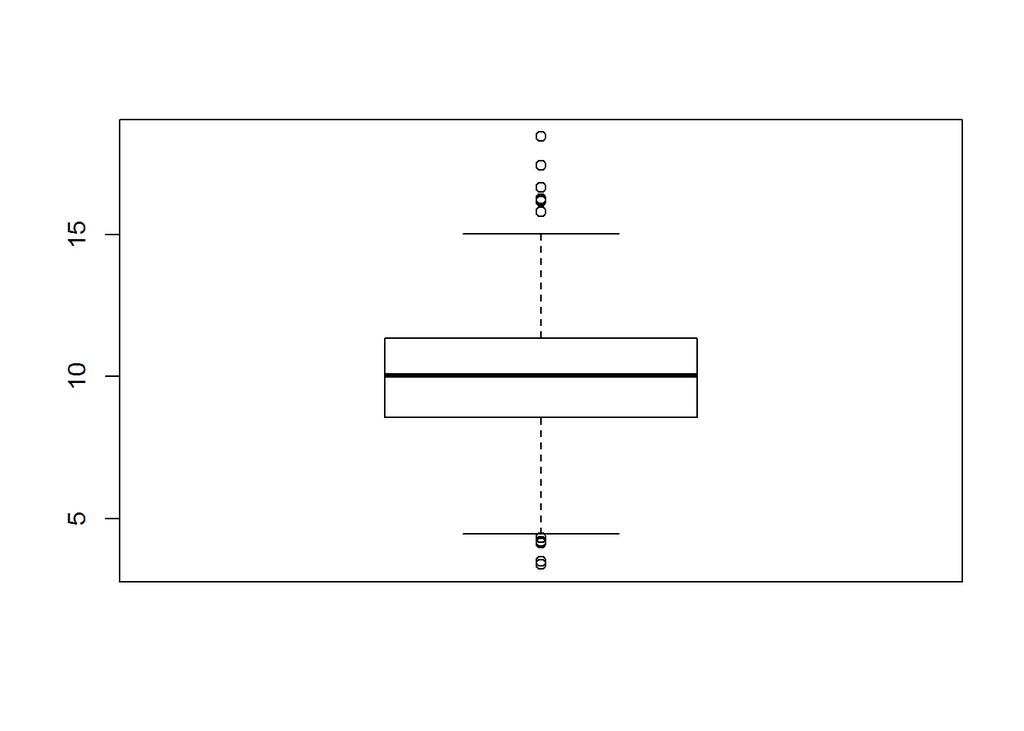

```r
boxplot(labdata1$pm25, range = 1.5)
```

`range`는 Box plot을 그릴 때 이용되는 변수로 상자 위아래의 날개 범위는 IQR(Interquartile Range) * `range`값입니다.

- 혹시 가로로 그리고 싶다면 다음과 같습니다.

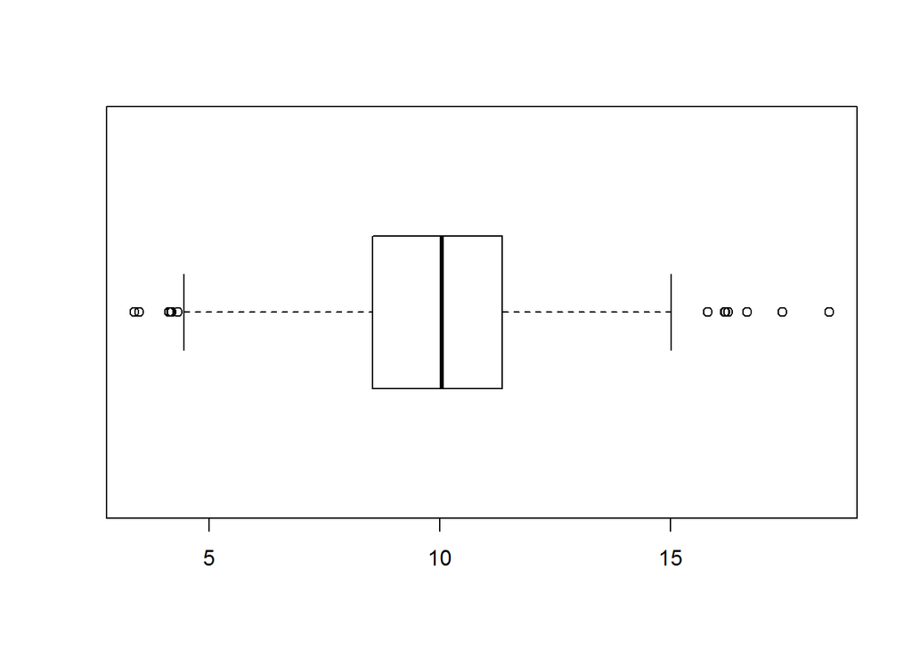

```r
boxplot(labdata1$pm25, horizontal = TRUE, range = 1.5)
```

- 여기에 색깔/제목/x축 이름/y축 이름을 추가하고자 한다면 다음과 같은 명령어 **title()** 을 추가하면 됩니다.

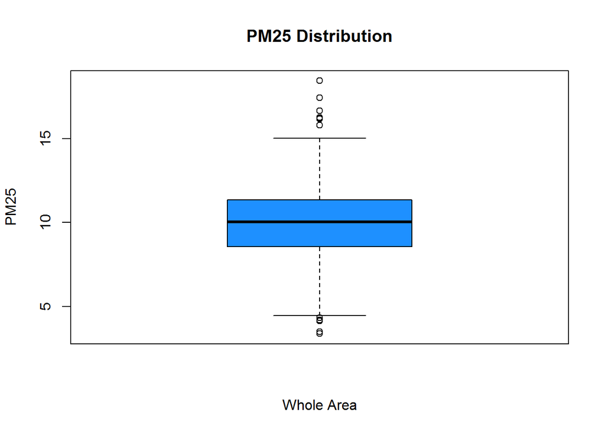

```r
boxplot(labdata1$pm25, col="dodgerblue")
title(main = "PM25 Distribution", xlab = "Whole Area", ylab = "PM25")
```

- 추가적으로 원하는 색깔은 Google에서 **R color cheetsheet** 을 검색하면 원하는 다양한 색깔을 찾을 수 있습니다.
- 마지막으로 범주를 추가하고자 한다면 다음과 같은 명령어 **legend()** 를 추가하면 됩니다.

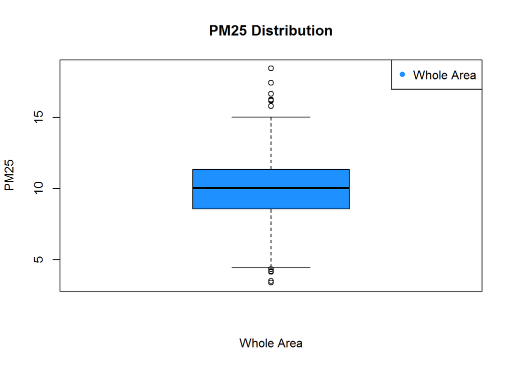

```r
boxplot(labdata1$pm25, col="dodgerblue")
title(main = "PM25 Distribution", xlab = "Whole Area", ylab = "PM25")
legend("topright", "Whole Area", pch = 16, col = "dodgerblue")
```

- 지역에 따라서 boxplot을 따로 그려보고자 한다면 다음과 같은 명령어를 입력하면 됩니다.

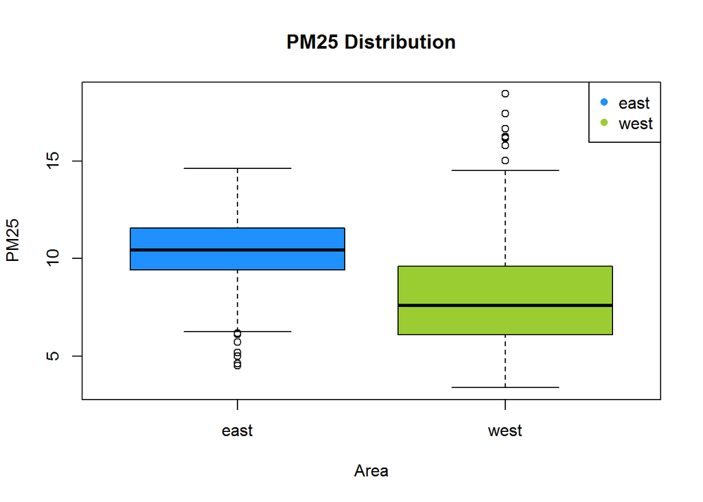

```r
boxplot(pm25 ~ region, data = labdata1, col=c("dodgerblue", "yellowgreen"))
title(main = "PM25 Distribution", xlab = "Area", ylab = "PM25")
legend("topright", c("east", "west"), pch = 16, col = c("dodgerblue", "yellowgreen"))
```

- 선형 회귀 분석에서 이용되었던 `pm25 ~ region`과 같은 형식의 입력변수를 `formula`라고 하는데, 보통 오른쪽 변수에 따라서 왼쪽 변수의 변화를 보겠다는 의미로 사용되기 때문에 이렇게 plotting에도 활용될 수 있습니다.
- 또한, `col`과 같은 곳에 여러 가지 색상을 입력할 경우에는 순서대로 `c()`안에 comma로 구분하여 넣어서 입력하면 됩니다. c는 column의 약자로, 입력을 1개만 하는 것이 아니라 column벡터화 하여 입력하겠다는 의미로, 한꺼번에 같은 종류의 값을 여러 가지 입력할 때 주로 이용됩니다.
- 자료의 형태에 따라 선택적인 사항이지만, 예를 들면 환경기준이 PM25값 8이라서 boxplot에 표시하고 싶다면 다음과 같은 명령어 **abline()** 를 추가하면 됩니다.

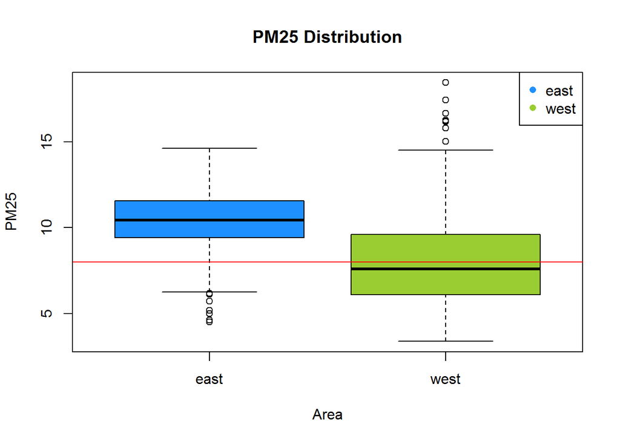

```r
boxplot(pm25 ~ region, data = labdata1, col=c("dodgerblue", "yellowgreen"))
title(main = "PM25 Distribution", xlab = "Area", ylab = "PM25")
legend("topright", c("east", "west"), pch = 16, col = c("dodgerblue", "yellowgreen"))
abline(h = 8, col = "red")
```

- `abline()`에는 수평선을 그리고 싶다면 `h = y좌표`, 수직선을 그리고 싶다면 `v = x좌표`, 임의의 직선을 그리고 싶다면 `a = y절편, b = 기울기`를 입력해주면 됩니다.
- R의 plotting system은 이와 같이 추가하고 싶고 꾸미고 싶고 바꾸고 싶은 것이 있다면 대부분 가능하다는 것이 장점입니다. 하지만 그러기 위해서는 많은 googling과 공부가 필수라는 것이 단점이라면 단점입니다.

## Scatter plot & 회귀 분석 시각화

Scatter plot이란 2가지 변수를 정하여 각각을 x좌표, y좌표로 갖는 그래프를 말하여, 보통 분석 전에 상관관계를 눈대중하거나 분석 후 회귀식과 함께 결과를 시각화할때 가장 많이 쓰이는 그래프입니다.

이번에는 실습1에서 회귀분석에 사용했던 `airquality`자료를 이용하겠습니다.

- 이용되는 함수는 **plot()** 함수이며, 가장 기본적으로는 **plot(x값이 있는 자료, y값이 있는 자료)** 의 형태로 작성해주면 됩니다.

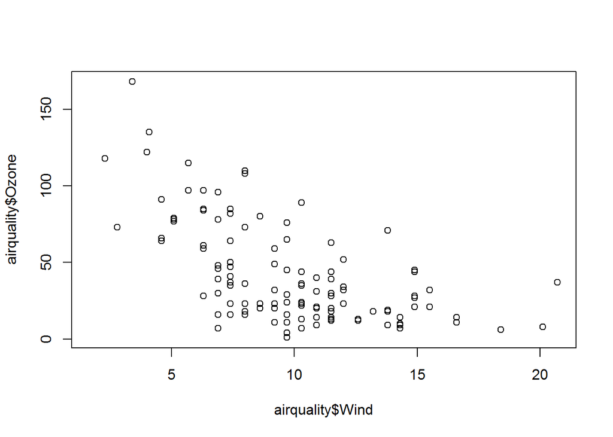

```r
plot(airquality$Wind, airquality$Ozone)
```

- plot 함수에서는 자동으로 x축과 y축의 제목을 생성하므로 위에서 배웠던 `title()`을 이용하려면, 다음과 같이 plot 안의 `xlab`과 `ylab`에 빈제목을 입력해주어야 한다.

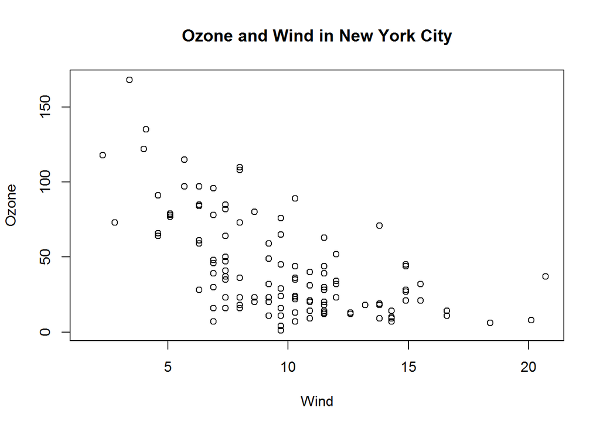

```r
plot(airquality$Wind, airquality$Ozone, xlab = "", ylab = "")
title(main = "Ozone and Wind in New York City", xlab = "Wind", ylab = "Ozone")
```

- 가장 기본적으로 비어있는 원으로 그려지는 그래프이지만 `pch`라는 변수를 이용하여 다음과 같이 모양을 바꿀 수 있습니다.

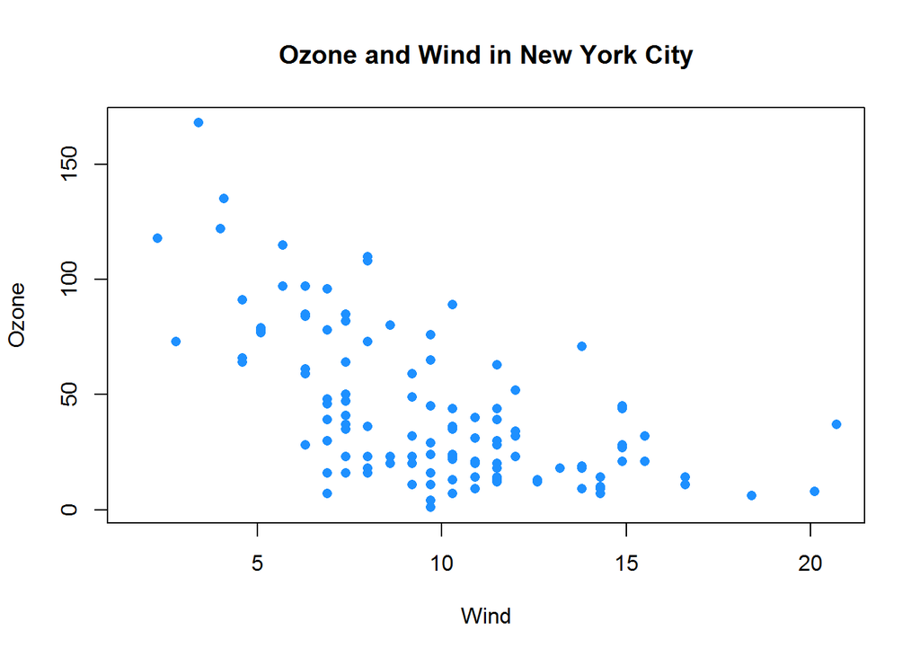

```r
plot(airquality$Wind, airquality$Ozone, pch = 16, col = "dodgerblue", xlab = "", ylab = "")
title(main = "Ozone and Wind in New York City", xlab = "Wind", ylab = "Ozone")
```

- 당연히 16번 모양이 어떤 모양인지 외울 수는 없습니다. `?pch`라는 명령어를 console에 쳐본다면 아래에 일람표가 있습니다.
- 이제는 회귀분석을 통해 얻을 수 있었던 식을 다음과 같이 **abline()** 함수를 이용하여 추가할 수 있습니다.

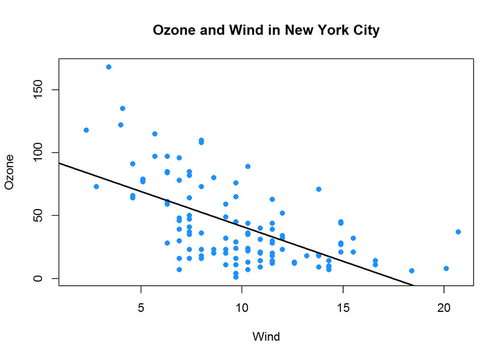

```r
plot(airquality$Wind, airquality$Ozone, pch = 16, col = "dodgerblue", xlab = "", ylab = "")
title(main = "Ozone and Wind in New York City", xlab = "Wind", ylab = "Ozone")
abline(model1, lwd = 2)
```

- 눈치채셨겠지만 회귀식의 intercept값과 slope의 값을 외울 필요는 없습니다. 분석결과를 저장해 놓았던 `model1`을 입력하면 자동적으로 intercept와 slope의 값을 찾아 그려줍니다.
- Excel에서와 같이 회귀식을 직접 입력하고 싶다면 그래프 안에 텍스트를 삽입하는 **text()** 함수를 이용할 수 있습니다.

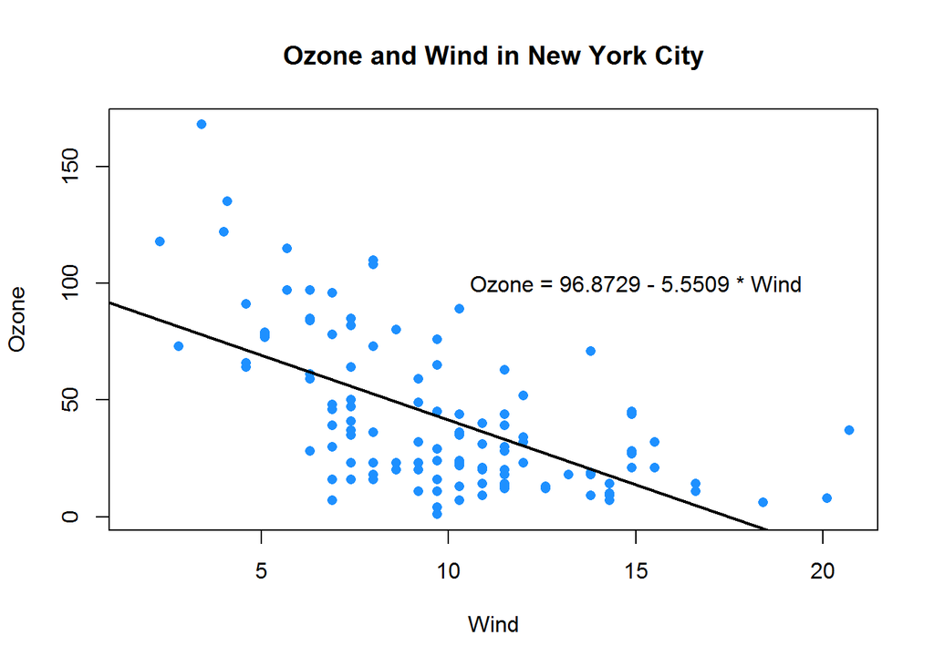

```r
plot(airquality$Wind, airquality$Ozone, pch = 16, col = "dodgerblue", xlab = "", ylab = "")
title(main = "Ozone and Wind in New York City", xlab = "Wind", ylab = "Ozone")
abline(model1, lwd = 2)
text(15, 100, labels = "Ozone = 96.8729 - 5.5509 * Wind")
```

- `text()`함수는 원하는 x,y 좌표에 원하는 문구를 `labels`에 입력하여 넣을 수 있는 함수입니다.
- `airquality` 자료에는 종속변수인 `Ozone`을 설명하기 위한 날씨에 관한 자료가 `Wind` 외에도, `Solar.R`, `Temp`가 있습니다. 이러한 상황에서는 본격적인 분석 전에 `airquality`가 각각의 변수에 대해서 어떤 경향을 보이는지 먼저 보고 싶을 때가 있습니다.

그럴 경우에는 다음과 같은 multi plot을 이용할 수 있습니다.

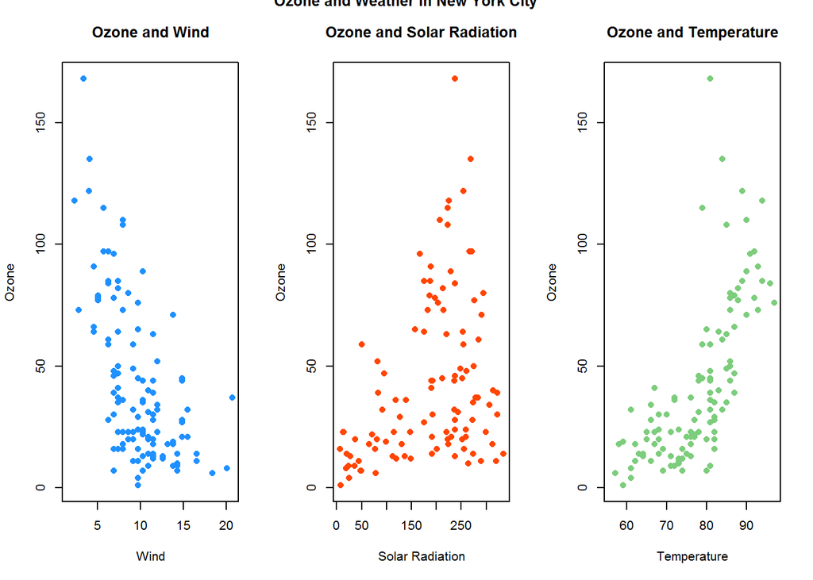

```r
par(mfrow = c(1, 3))

plot(airquality$Wind, airquality$Ozone, pch = 16, col = "dodgerblue", xlab = "", ylab = "")
title(main = "Ozone and Wind", xlab = "Wind", ylab = "Ozone")

plot(airquality$Solar.R, airquality$Ozone, pch = 16, col = "orangered", xlab = "", ylab = "")
title(main = "Ozone and Solar Radiation", xlab = "Solar Radiation", ylab = "Ozone")

plot(airquality$Temp, airquality$Ozone, pch = 16, col = "palegreen3", xlab = "", ylab = "")
title(main = "Ozone and Temperature", xlab = "Temperature", ylab = "Ozone")

title("Ozone and Weather in New York City", outer = TRUE)
```

- `par()`는 R에서 Graphic Parameter를 바꾸고 싶을 때 이용하는 함수입니다. 이러한 Graphic parameter에는 모두 기본값들이 저장되어 있습니다.
- `par(mfrow = c(1,3))`이라는 명령은 현재 한 화면에 그래프를 1행, 3열로 총 3개를 그릴 수 있게 하라는 명령어입니다. 기본값은 `mfrow = c(1,1)` 즉, 1행 1열로 1개만 그리도록 설정이 되어 있습니다.
- 이렇게 설정을 바꾼 후 순서대로 3개의 그래프를 그려주면 자연스럽게 3개의 그래프가 1행 3열로 배열됩니다.
- 마지막 `title()`함수에는 `outer = TRUE`라는 것이 추가되어 있는데, 그림판의 바깥쪽 여백에 이 제목을 추가하라는 뜻입니다. 안쪽 여백이란 각 3개의 그래프 주변의 여백을 뜻하며, 바깥쪽 여백이란 3개의 그래프를 아우르는 전체 그림판의 바깥쪽 여백을 의미합니다.
- 여백조정없이 그래프만 3열로 세운다면 위와 같이 전체 제목이 가려질 우려가 있으므로, 다음과 같이 여백과 글씨크기를 조정할 수 있습니다.

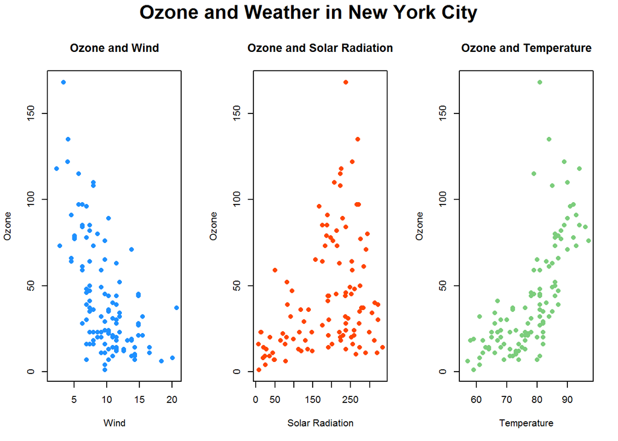

```r
par(mfrow = c(1, 3), oma = c(0,0,2,0))

plot(airquality$Wind, airquality$Ozone, pch = 16, col = "dodgerblue", xlab = "", ylab = "")
title(main = "Ozone and Wind", xlab = "Wind", ylab = "Ozone")

plot(airquality$Solar.R, airquality$Ozone, pch = 16, col = "orangered", xlab = "", ylab = "")
title(main = "Ozone and Solar Radiation", xlab = "Solar Radiation", ylab = "Ozone")

plot(airquality$Temp, airquality$Ozone, pch = 16, col = "palegreen3", xlab = "", ylab = "")
title(main = "Ozone and Temperature", xlab = "Temperature", ylab = "Ozone")

title(main = "Ozone and Weather in New York City", outer = TRUE, cex.main = 2)
```

- `par()` 안에 추가된 `oma = c(0,0,2,0)`은 바깥쪽 여백 (outer margin)을 설정해줍니다. 순서는 (하, 좌, 상, 우)로, 아래쪽부터 시계방향입니다.
- 또한, 마지막 `title()` 안에 추가된 `cex.main = 2`는 main title의 글씨크기를 2로 한다는 명령어로, 기본값은 1입니다.